# Shape inference by data assimilation: Poisson equation

### ~ Fictitious domain solver using Nitsche's method and level sets

Author: Alexandros Kontogiannis

This notebook does not use any external FEM library (e.g. FEniCS, deal.ii).  
The $\texttt{nitsche_poisson}$ library is implemented in Python, by the author, for this specific toy problem.

February 2020, Cambridge

## 0) Basic Formulation

We derive an algorithm that infers the shape of a domain $\Omega \subset\subset V$, with $V\subset \mathbb{R}^2$, by assimilating data that correspond to the 'true' solution. That is, given a boundary value problem having solution $u$ in $\Omega$, and measurements $u^\star$ in $U \subseteq V$ that correspond to the 'true' value, find the domain $\Omega^\star$ that minimizes the $L^2$-norm of $u-u^\star$. Certainly, perturbations of $\Omega$ correspond to perturbations of the solution $u$. The methodology is as follows

- Derive the boundary value problem (BVP) governing the field of shape derivatives for the given problem (Poisson problem in our case).
- Define the error functional and find its sensitivity w.r.t. shape perturbations.
- Combine the BVP of shape derivatives and the error functional to replace the unknown terms of the latter. This leads to an adjoint problem, that once solved, the shape derivative of the error functional is computed in one shot.

#### $\cdot$ Step 1 $\cdot$ The field of shape derivatives

First we write the classical Poisson problem

\begin{gather} \begin{cases} -\Delta u = f \ &\textrm{in}\ \Omega \\ \hspace{0.68cm} u = 0 \ &\textrm{on}\ \partial \Omega \end{cases}\tag{$\dagger$} \end{gather}

for $f \in C^2(\Omega)$. Relaxing the regularity assumption on $f$, we write the weak form for $f \in L^2(\Omega)$,

\begin{gather} \int_\Omega \nabla u \nabla \phi = \int_\Omega f \phi \quad,\quad \phi \in H^1_0(\Omega) \end{gather}

We consider that $\Omega$ is a moving domain ($\Omega_\tau, \tau \in [0,\epsilon]$), and we compute its shape derivatives

\begin{align} d_{\mathscr{V}} \Big( \int_\Omega \nabla u \nabla \phi\Big) &= d_{\mathscr{V}}\Big(\int_\Omega f \phi \Big) \quad,\quad \phi \in \mathscr{D}(\Omega) \nonumber \\ \int_\Omega \big(\nabla u \nabla\phi \big)' + \int_{\partial \Omega} \big(\nabla u \nabla \phi)({\mathscr{V}}\cdot\nu) &= \int_\Omega \big(f\phi \big)' + \int_{\partial \Omega}\big(f\phi \big)({\mathscr{V}}\cdot\nu) \nonumber \\ \int_\Omega \nabla u' \nabla\phi &= \int_\Omega f'\phi \end{align}

where ${\mathscr{V}}$ is the speed field. For the Dirichlet boundary condition we find

\begin{align} d_{\mathscr{V}}\Big(\int_{\partial\Omega} u\phi \Big) &= 0 \quad,\quad \phi \in \mathscr{D}(\mathbb{R}^n) \nonumber \\ \int_{\partial\Omega} (u\phi)' + (\nu\cdot\nabla + \kappa)u\phi({\mathscr{V}}\cdot\nu) &= 0 \nonumber \\ \int_{\partial\Omega} u'\phi + \big(\nu\cdot\nabla (u\phi) + \kappa u\phi\big)({\mathscr{V}}\cdot\nu) &= 0 \nonumber \\ \int_{\partial\Omega} \big(u' + (\nu\cdot\nabla u)({\mathscr{V}}\cdot\nu)\big)\phi &= 0 \quad,\quad (u\big\vert_{\partial\Omega}=0) \end{align}

The above weak forms translate to the following boundary value problem -in classical form- for the shape derivatives

\begin{gather} \begin{cases} -\Delta u' = f' \ &\textrm{in}\ \Omega \\ \hspace{0.68cm} u' = -(\nu\cdot\nabla u)({\mathscr{V}}\cdot\nu) \ &\textrm{on}\ \partial \Omega \end{cases} \label{eq:shape_sens} \tag{$\ddagger$} \end{gather}

If the forcing term $f$ does not depend on perturbations of $\Omega$, then $f' \equiv 0$ and we need to solve a Dirichlet problem for the Laplace equation.

#### $\cdot$ Step 2 $\cdot$ Shape derivative of the error functional

Since $u$ and $u^\star$ are only defined in $\Omega$ and $U$, respectively, for integrals defined in a larger domain, we identify these functions with their trivial extension. Then, we can write

\begin{align} \mathscr{J}(u)(V) &= \frac{1}{2}\int_V (u-u^\star)^2 \\ &= \frac{1}{2}\int_\Omega (u-u^\star)^2 + \frac{1}{2}\int_{V\setminus\Omega} (u-u^\star)^2 \end{align}

The shape derivative reads

\begin{align} d_{\mathscr{V}} \mathscr{J}(u)(V) &= \frac{1}{2} \Big(\int_\Omega \big( (u-u^\star)^2\big)' + \int_{\partial \Omega^+} (u-u^\star)^2 {\mathscr{V}}\cdot\nu + \int_{\Omega\setminus V} \big( (u-u^\star)^2\big)' + \int_{\partial \Omega^-} (u-u^\star)^2 {\mathscr{V}}\cdot\nu\Big) \nonumber \\ &= \int_\Omega (u-u^\star)u' + \frac{1}{2}\int_{\partial \Omega^+} (u-u^\star)^2 {\mathscr{V}}\cdot\nu - \frac{1}{2}\int_{\partial \Omega^+} (u-u^\star)^2 {\mathscr{V}}\cdot\nu \label{eq:obj_shape_deriv}\\ &= \int_\Omega (u-u^\star)u' = d_{\mathscr{V}} \mathscr{J}(u,u^\star,u')(\Omega) \nonumber \end{align}

To compute $d_{\mathscr{V}} \mathscr{J}$ we need $u,u^\star$ and $u'$. The shape sensitivity field $u'$ can be found from the boundary value problem \eqref{eq:shape_sens}. However, we have to prescribe the speed field $\mathscr{V}$, as it is needed to define the boundary condition. This is not exactly what we want, what we want is to find the optimal speed field. In the next subsection we describe the procedure.

#### $\cdot$ Step 3 $\cdot$ Constructing the adjoint problem

We start with a weak form of the field equation for the shape derivative $u'$, defined only in $\Omega$

\begin{align} \int_\Omega -\Delta u' v &= \int_\Omega f'v \quad,\quad v \in H^2(\Omega)\cap H^1_0(\Omega) \nonumber \\ \int_\Omega \nabla u' \nabla v &= \int_\Omega f'v \nonumber \\ -\int_\Omega u' \Delta v + \int_{\partial \Omega} u' \nabla v\cdot\nu &= \int_\Omega f'v \end{align}

But from the BVP \eqref{eq:shape_sens} we already know $u'$ on $\partial\Omega$ so we write

\begin{gather} -\int_\Omega u' \Delta v = \int_\Omega f'v + \int_{\partial \Omega} (\nu\cdot\nabla u)({\mathscr{V}}\cdot\nu) (\nabla v\cdot\nu) \label{eq:weak_shape_deriv} \end{gather}

Now observe that we can replace the unknown term $u'$ by setting the adjoint problem for $v$

\begin{gather} \begin{cases} -\Delta v = u-u^\star \ &\textrm{in}\ \Omega \\ \hspace{0.68cm} v = 0 \ &\textrm{on}\ \partial \Omega \end{cases} \tag{$*$} \end{gather}

Then, we obtain

\begin{align} \int_\Omega (u-u^\star)u' = -\int_\Omega u'\Delta v = \int_{\partial \Omega} (\nu\cdot\nabla u)({\mathscr{V}}\cdot\nu) (\nabla v\cdot\nu) \end{align}

for $f'\equiv 0$. Finally, the shape derivative of the error functional takes the form

\begin{align} d_{\mathscr{V}}\mathscr{J}(u,u^\star,v)(\Omega) =\int_{\partial \Omega} (\nu\cdot\nabla u) (\nabla v\cdot\nu) {\mathscr{V}}\cdot\nu \end{align}

Allowing speed fields that have only normal components (Hadamard parameterization), we write $\mathscr{V} = \zeta \nu$, and we see that the optimal speed field is for

\begin{gather} \boxed{ \zeta = -(\nu\cdot\nabla u) (\nabla v\cdot\nu)\big\vert_{\partial\Omega}} \end{gather}

leading to a gradient flow where $d_{\mathscr{V}} \mathscr{J} = -\int_{\partial\Omega} \zeta^2$ which is always non-positive.

We may wish to project $\zeta$ to another basis, such as a B-spline or a trigonometric series, as there are many ways to parameterize the boundary $\partial\Omega$.

An implementation of the above methods follows.

```python
# Libraries
import numpy as np; import copy, time
import matplotlib; import matplotlib.pyplot as plt; from matplotlib import rc,cm
%matplotlib inline
from IPython.display import set_matplotlib_formats
set_matplotlib_formats('png','pdf'); matplotlib.rcParams['mathtext.fontset'] = 'stix'; matplotlib.rcParams['font.family'] = 'STIXGeneral'
rc('text', usetex=True); np.random.seed(0)
```

```python
# Own modules
import sys; sys.path.append('/home/ale3andros/cambridge/codes/pyNitschePoisson')
import npparams as params; from nitsche_poisson import *; import sgndistfield as sgndist
```

## 2) Shape inference algorithm

# Modules

### Solver for the Poisson problem for $u$

```python
def primal_solver(rho=None,ls=None):
    # Setup primal solver
    primal_params = params.Parameters()
    primal_params.set_domain_limits(dom_lims)
    primal_params.set_cell_number(N_cells)
    primal_params.solve_internal_domain(True)
    primal_params.set_rhs_func(f_rhs)
    primal_params.set_cut_fe_gamma([gamma,gamma1])
    primal_params.set_suppress_output(True)
    primal_params.set_interface_in_polar_coords(rho)
    primal_params.set_level_set_function(ls)
    primal = NitschePoisson(primal_params)
    primal.run()
    return primal
```

### Solver for the adjoint Poisson problem for $v$

```python
# Solver for the adjoint Poisson problem
# -----------------------------------------------------------------------------
def adjoint_solver(f_adj,rho=None,ls=None):
    # Setup adjoint state solver
    adjoint_params = params.Parameters()
    adjoint_params.set_domain_limits(dom_lims)
    adjoint_params.set_cell_number(N_cells)
    adjoint_params.solve_internal_domain(True)
    adjoint_params.set_rhs_func(f_adj)
    adjoint_params.set_cut_fe_gamma([gamma,gamma1])
    adjoint_params.set_suppress_output(True)
    adjoint_params.set_interface_in_polar_coords(rho)
    adjoint_params.set_level_set_function(ls)
    adjoint = NitschePoisson(adjoint_params)
    adjoint.run()
    return adjoint
```

### Class implementing the shape inference algorithm

```python
# Shape inference module
'''
** Description **
'''
# -----------------------------------------------------------------------------
class ShapeInference():
    def __init__(self,u_meas,*args,**kwargs):
        # User-defined parameters
        self.iter          = 0
        self.speed_field   = []
        self.primal        = []
        self.adjoint       = []
        self.u_meas        = u_meas
        self.ls            = []
        self.phi           = []
        self.phi_eps       = kwargs.get('phi_eps',5e-3)
        self.zeta_ext_tau  = kwargs.get('zeta_ext_tau',15.)
        self.save_opt_prog = kwargs.get('save_opt_prog',False)
        self.I             = []

    def compute_optimal_speed_field(self):
        self.phi = sgndist.SignedDistanceField(self.primal.params,alpha=1.,\
                                          eps=self.phi_eps,heat_flow_bc='Neum',\
                                          plot=False,use_existing_cgeo=False)
        f_adj        = (self.primal.solution2-self.u_meas).flatten()
        self.adjoint = adjoint_solver(f_adj,None,self.ls[-1])
        # Offset level-set: gradient is  computed 2*h away from the boundary
        grad_cgeo = cut_geo.CutGeo(self.ls[-1].flatten()+2*self.primal.h)
        grad_cgeo.locate_and_compute(self.primal)
        # Compute the shape gradient
        shape_spd,zeta,interface_pt = methods.compute_shape_speed_field(\
                                        self.primal,self.adjoint,grad_cgeo,True)
        zeta_0 = list(shape_spd[:,2])
        # Compute extension of optimal 'speed' field (shape gradient)
        normal_extension = self.phi.compute_unit_normal_vec_extension(None,\
                                                                    self.ls[-1])
        zeta_ext = self.phi.extend_boundary_function(self.zeta_ext_tau,zeta_0,\
                                          copy.deepcopy(normal_extension),None,\
                                 grad_cgeo.level_set,grad_cgeo.inside_node_indx)
        tmp = np.column_stack((zeta_ext,zeta_ext))
        self.speed_field = np.multiply(tmp,normal_extension)

    def gradient_flow(self,tau):
        phi_0  = self.ls[-1]#self.primal.level_set.level_set2
        ls_new = self.phi.propagate_signed_dist_function(phi_0.flatten(),tau,\
                                                   -self.speed_field,None,phi_0)
        return ls_new.reshape((N_cells+1),(N_cells+1))

    def compute_objective(self,primal):
        flow_matching  = 1./2*methods.compute_l2_norm(primal,\
                                        primal.solution-self.u_meas.flatten(),'everywhere')**2
        return flow_matching

    def plot_primal_and_dual(self):
        methods.plot_image(self.primal,0)
        methods.plot_image(self.adjoint,0)

    def infer_shape_from_data(self,*args,**kwargs):
        # params
        tau_0    = kwargs.get('tau_0',0.1)
        obj_tol  = kwargs.get('obj_tol',1e-6)
        max_ls   = kwargs.get('max_ls',15)
        max_iter = kwargs.get('max_iter',200)

        # zero-th iteration
        self.primal = primal_solver(None,self.ls[-1]) # evaluate primal problem
        self.I.append(self.compute_objective(self.primal)) # evaluate cost

        term_crit = False; tau = tau_0
        while(not term_crit and self.iter <= max_iter):

            # save solution and boundary at each iteration
            if self.save_opt_prog == True:
                np.save('sol_'+"{:03d}".format(self.iter)+'.npy',\
                                                           self.primal.solution)
                np.save('phi_'+"{:03d}".format(self.iter)+'.npy',\
                                                     self.primal.cgeo.level_set)

            # optimization progress
            print("\n> ITER {:d} | OBJ {:e} |".format(self.iter,self.I[-1]))

            # line search direction
            self.compute_optimal_speed_field()

            # initiate line search with dynamic step size
            I_search = self.I[-1]; ls_step = 0
            while self.I[-1] <= I_search:
                # gradient flow (fw Euler)
                phi_new  = self.gradient_flow(tau)
                # evaluate primal problem
                primal   = primal_solver(None,phi_new)
                # compute new objective
                I_search = self.compute_objective(primal)

                # line search progress
                print("\n -- LS_STEP {:d} | OBJ {:e} | TAU {:.8f}".\
                                                   format(ls_step,I_search,tau))

                # reduce pseudo-time tau if cost is not reduced
                tau *= 0.5 if I_search >= self.I[-1] else 1.
                ls_step += 1

                # terminate if line search step exceeds user-specified limit
                if ls_step > max_ls:
                    term_crit = True; break

            # update iteration step if LS succeeded, otherwise terminate
            if (ls_step <= max_ls):
                self.I.append(I_search); self.ls.append(phi_new)
                self.primal = primal; tau *= 1.5
                if abs(self.I[-1]-self.I[-2])/(self.I[-1]) > obj_tol:
                    self.iter += 1
                else:
                    term_crit = True
            else:
                term_crit = True
```

```python
def plot_shape_inf_results(phi_0,algo_,signal,u_meas):
    primal0 = primal_solver(None,phi_0)
    vmax,vmin= methods.detect_extrema_inside_domain(signal,signal.solution)
    colormap = cm.PuRd
    fig, ax = plt.subplots(1,3,figsize=(20,5),dpi=128);
    x_llim = dom_lims[0]; x_ulim = dom_lims[1]
    y_llim = dom_lims[0]; y_ulim = dom_lims[1]
    im1=ax[0].imshow(primal0.solution2,interpolation='bilinear',cmap=colormap,\
                     origin='lower', extent=[x_llim, x_ulim,y_llim, y_ulim],\
                     aspect="auto",vmin=vmin, vmax=vmax)
    im2=ax[2].imshow(algo_.primal.solution2,interpolation='bilinear',\
                     cmap=colormap,origin='lower',\
                    extent=[x_llim, x_ulim,y_llim, y_ulim],\
                     aspect="auto",vmin=vmin, vmax=vmax)
    im3=ax[1].imshow(u_meas,cmap=colormap,origin='lower',\
                     extent=[x_llim, x_ulim,y_llim, y_ulim],aspect="auto",\
                     vmin=vmin, vmax=vmax)
    ax[0].set(xlabel='x',ylabel='y',title='Model (pure)')
    ax[2].set(xlabel='x',ylabel='y',title='Model (DA)')
    ax[1].set(xlabel='x',ylabel='y',title='Artificial MRV signal')
    fig.colorbar(im2,ax=ax); plt.show()
    # Convergence of the $L^2$-error norm in $V \equiv (-1.25,1.25)^2$
    fig = plt.figure(dpi=96); ax = fig.add_subplot(111); ax.set_yscale('log'); ax.set_xlabel('Iteration'); ax.set_xlim(0,len(algo.I))
    x_avg = len(algo_.I)/2. ; y_avg = 0.5*(max(algo_.I)+min(algo_.I))
    ax.text(x_avg, y_avg,r'$$\frac{1}{2}||u-u^\star||^2_{L^2(V)}$$',fontsize=16); ax.plot(algo_.I,'k-'); plt.show()
    np.save('shape_inf_conv_1.npy',algo_.I)
```

### Artificial MRV signal $u^\star$

```python
# Create a dummy MRI signal (we assume the signal satisfies the Poisson eq.)
# -------------------------------------------------------------------------
def create_dummy_mri_signal(noise_param=0.):
    signal_params = params.Parameters()
    signal_params.set_domain_limits(dom_lims)
    signal_params.set_cell_number(N_cells)
    signal_params.solve_internal_domain(True)
    signal_params.set_rhs_func(f_rhs)
    signal_params.set_cut_fe_gamma([gamma,gamma1])
    signal_params.set_suppress_output(True)
    n_curve = 10**4; x = np.linspace(-np.pi,np.pi,n_curve);
    r = 0.7-0.175*np.cos(5*x)-0.05*np.cos(6*x)+0.03*np.sin(9*x)
    rho = [x,r]; signal_params.set_interface_in_polar_coords(rho)
    signal = NitschePoisson(signal_params)
    signal.run()
    # add noise
    n_size = signal.solution2.shape[0]
    u_meas = signal.solution2 + noise_param*np.random.randn(n_size,n_size)
    return signal,u_meas
```

```python
# Plot artificial MRI signal
def plot_dummy_mri_signal(signal,u_meas):
    colormap = cm.PuRd; fig, ax = plt.subplots(1,2,figsize=(15,5),dpi=128);
    vmax,vmin= methods.detect_extrema_inside_domain(signal,signal.solution)
    x_llim = dom_lims[0]; x_ulim = dom_lims[1]
    y_llim = dom_lims[0]; y_ulim = dom_lims[1]
    ax[0].contour(signal.x,signal.y,u_meas,10,cmap=colormap,vmin=vmin,vmax=vmax)
    ax[0].set(xlabel='x',ylabel='y',title='Signal (contour)')
    im=ax[1].imshow(u_meas,interpolation='bilinear',cmap=colormap,
           origin='lower',extent=[x_llim, x_ulim,y_llim, y_ulim],aspect="auto",\
           vmin=vmin,vmax=vmax); fig.colorbar(im, ax=ax)
    ax[1].set(xlabel='x',ylabel='y',title='Signal (image)'); plt.show()
```

# Shape inference method

```python
# General parameters
# -------------------------------------------------------------------------
dom_lims = [-1.25,1.25]; N_cells = 200
gamma    = 10; gamma1 = 0.1
f_rhs    = 1.
```

## Case 1 (without noise)

### MRI signal without noise (ideal)

```python
noise_param = 0.0
signal,u_meas = create_dummy_mri_signal(noise_param)
```

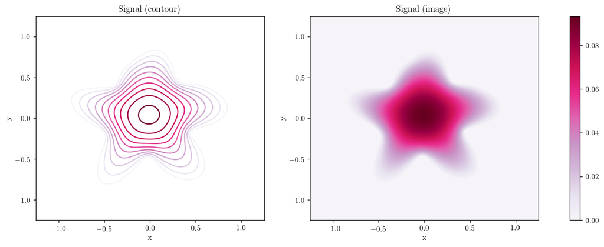

```python
plot_dummy_mri_signal(signal,u_meas)
```

### Recovering the shape of the domain starting from a disk

```python
# Shape inference
# -------------------------------------------------------------------------
algo = ShapeInference(u_meas,phi_eps=5e-3,zeta_ext_tau=15.,save_opt_prog=False)

# Initial guess (just a disk)
x_0 = 0.6; y_0 = 0.; r_0 = 0.3
x = np.linspace(dom_lims[0],dom_lims[1],N_cells+1)
xx,yy = np.meshgrid(x,x); phi_0 = -(r_0-np.sqrt((xx-x_0)**2+(yy-y_0)**2))
algo.ls.append(phi_0)

# Run shape inference method
start = time.time()
algo.infer_shape_from_data(tau_0=0.1,obj_tol=1e-6,max_ls=10,max_iter=100)
end   = time.time()
print('\n- Optimization terminated after {:.2f} sec'.format(end-start))
```

```
> ITER 0 | OBJ 1.779145e-03 |

 -- LS_STEP 0 | OBJ 1.746074e-03 | TAU 0.10000000

> ITER 1 | OBJ 1.746074e-03 |

 -- LS_STEP 0 | OBJ 1.673037e-03 | TAU 0.15000000

> ITER 2 | OBJ 1.673037e-03 |

 -- LS_STEP 0 | OBJ 1.460226e-03 | TAU 0.22500000

> ITER 3 | OBJ 1.460226e-03 |

 -- LS_STEP 0 | OBJ 9.051854e-04 | TAU 0.33750000

> ITER 4 | OBJ 9.051854e-04 |

 -- LS_STEP 0 | OBJ 1.459419e-04 | TAU 0.50625000

> ITER 5 | OBJ 1.459419e-04 |

 -- LS_STEP 0 | OBJ 9.829646e-04 | TAU 0.75937500

 -- LS_STEP 1 | OBJ 3.547897e-04 | TAU 0.37968750

 -- LS_STEP 2 | OBJ 1.086966e-04 | TAU 0.18984375

> ITER 6 | OBJ 1.086966e-04 |

 -- LS_STEP 0 | OBJ 1.286872e-04 | TAU 0.28476563

 -- LS_STEP 1 | OBJ 6.583913e-05 | TAU 0.14238281

> ITER 7 | OBJ 6.583913e-05 |

 -- LS_STEP 0 | OBJ 2.918879e-04 | TAU 0.21357422

 -- LS_STEP 1 | OBJ 8.790790e-05 | TAU 0.10678711

```

[output cut: 480 more lines]

```
 -- LS_STEP 1 | OBJ 2.231983e-07 | TAU 0.00195909

> ITER 99 | OBJ 2.231983e-07 |

 -- LS_STEP 0 | OBJ 2.297704e-07 | TAU 0.00293863

 -- LS_STEP 1 | OBJ 2.235325e-07 | TAU 0.00146932

 -- LS_STEP 2 | OBJ 2.229405e-07 | TAU 0.00073466

> ITER 100 | OBJ 2.229405e-07 |

 -- LS_STEP 0 | OBJ 2.195443e-07 | TAU 0.00110199

- Optimization terminated after 2309.98 sec
```

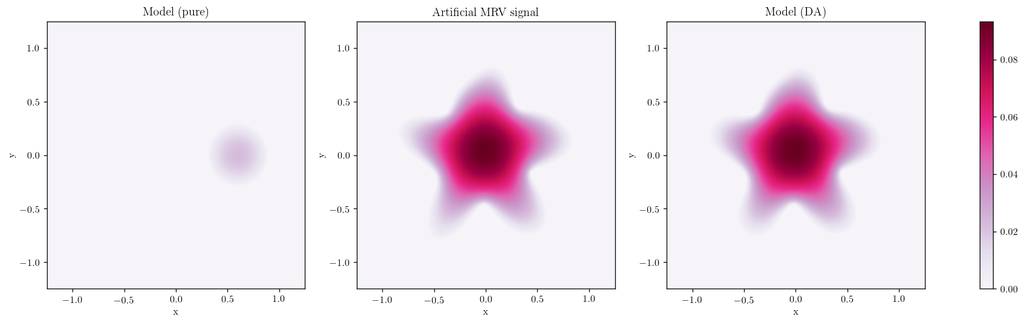

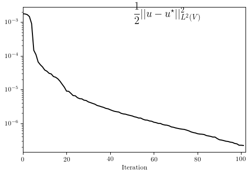

```python
plot_shape_inf_results(phi_0,algo,signal,u_meas)
```

## Case 2 (with noise)

### MRI signal with Gaussian noise

```python
noise_param = 0.025
signal_1,u_meas_1 = create_dummy_mri_signal(noise_param)
```

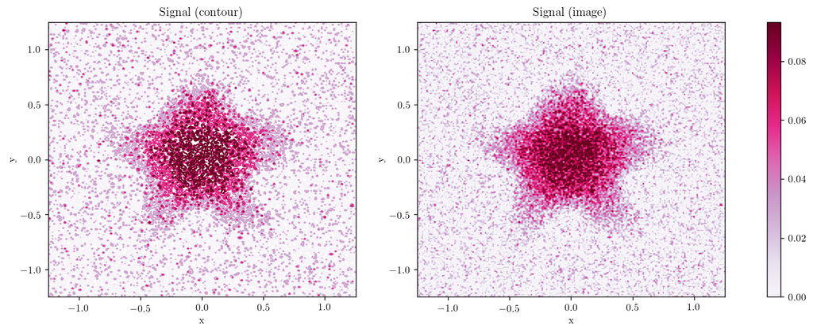

```python
plot_dummy_mri_signal(signal_1,u_meas_1)
```

### Recovering the shape of the domain starting from a disk

```python
# Shape inference
# -------------------------------------------------------------------------
algo_1 = ShapeInference(u_meas_1,phi_eps=5e-3,zeta_ext_tau=15.,save_opt_prog=False)

# Initial guess (just a disk)
x_0 = 0.6; y_0 = 0.; r_0 = 0.3
x = np.linspace(dom_lims[0],dom_lims[1],N_cells+1)
xx,yy = np.meshgrid(x,x); phi_0 = -(r_0-np.sqrt((xx-x_0)**2+(yy-y_0)**2))
algo_1.ls.append(phi_0)

# Run shape inference method
start = time.time()
algo_1.infer_shape_from_data(tau_0=0.1,obj_tol=1e-6,max_ls=10,max_iter=100)
end   = time.time()
print('\n- Optimization terminated after {:.2f} sec'.format(end-start))
```

```
> ITER 0 | OBJ 2.624698e-03 |

 -- LS_STEP 0 | OBJ 2.594294e-03 | TAU 0.10000000

> ITER 1 | OBJ 2.594294e-03 |

 -- LS_STEP 0 | OBJ 2.517623e-03 | TAU 0.15000000

> ITER 2 | OBJ 2.517623e-03 |

 -- LS_STEP 0 | OBJ 2.340556e-03 | TAU 0.22500000

> ITER 3 | OBJ 2.340556e-03 |

 -- LS_STEP 0 | OBJ 1.977865e-03 | TAU 0.33750000

> ITER 4 | OBJ 1.977865e-03 |

 -- LS_STEP 0 | OBJ 1.162227e-03 | TAU 0.50625000

> ITER 5 | OBJ 1.162227e-03 |

 -- LS_STEP 0 | OBJ 1.386424e-03 | TAU 0.75937500

 -- LS_STEP 1 | OBJ 9.818246e-04 | TAU 0.37968750

> ITER 6 | OBJ 9.818246e-04 |

 -- LS_STEP 0 | OBJ 9.393090e-04 | TAU 0.56953125

> ITER 7 | OBJ 9.393090e-04 |

 -- LS_STEP 0 | OBJ 2.310503e-03 | TAU 0.85429688

 -- LS_STEP 1 | OBJ 1.648255e-03 | TAU 0.42714844

 -- LS_STEP 2 | OBJ 1.071639e-03 | TAU 0.21357422

 -- LS_STEP 3 | OBJ 9.212012e-04 | TAU 0.10678711

```

[output cut: 162 more lines]

```
 -- LS_STEP 4 | OBJ 8.644560e-04 | TAU 0.00081366

 -- LS_STEP 5 | OBJ 8.644484e-04 | TAU 0.00040683

 -- LS_STEP 6 | OBJ 8.644297e-04 | TAU 0.00020342

 -- LS_STEP 7 | OBJ 8.644246e-04 | TAU 0.00010171

 -- LS_STEP 8 | OBJ 8.644162e-04 | TAU 0.00005085

 -- LS_STEP 9 | OBJ 8.644166e-04 | TAU 0.00002543

 -- LS_STEP 10 | OBJ 8.644168e-04 | TAU 0.00001271

- Optimization terminated after 909.79 sec
```

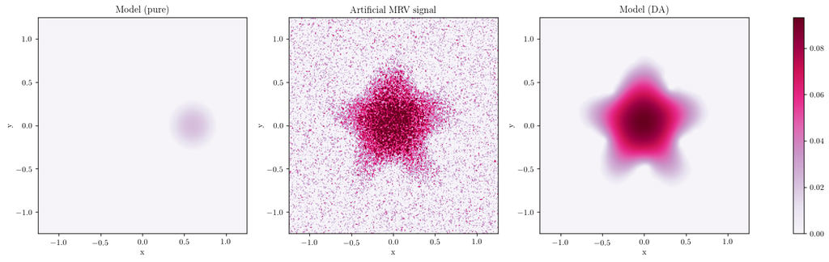

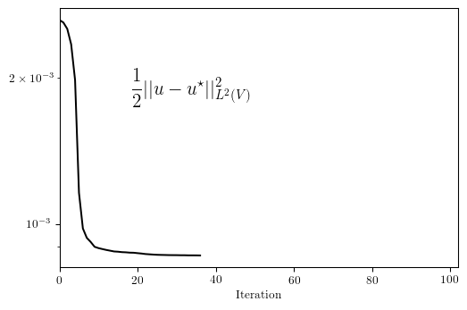

```python
plot_shape_inf_results(phi_0,algo_1,signal_1,u_meas_1)
```